# Bayes Notes

mbh

18/06/2017

## Discrete Bayes Rule

$P[A_i|B]=\dfrac{P[B|A_i]P[A_i]}{P[B]}=\dfrac{P[B|A_i]P[A_i]}{\sum_{j=1}^nP[B|A_j]P[A_j]}$

## Continuous Bayes Rule

$\pi^*(p|x)=\dfrac{P(x|p)\pi(p)}{\int^1_0P(x|p)\pi(p)dp}$

## Beta distribution

$f(p)=\dfrac{\Gamma(\alpha+\beta)}{\Gamma(\alpha)+\Gamma(\beta)}p^{\alpha-1}(1-p)^{\beta-1}$

where  
$0\le p\le1$, $\alpha,\beta>0$  
$\Gamma(n)=(n-1)!$ - the gamma function

### Conjugacy

if pdf for prior used with conjugate dist for likelihood, then pdf for posterior wiull come from same families, but with updated parameter values.

### Beta distribution

defined on iternval 0-1 so useful as pdf for bounded priors eg probability of success in binomial dist.

#### Prior beliefs

- Binomial with known $n$ and unknown $p$
- beta pdf $beta(a,b)$

#### observe

- $x$ successes in $n$ trials

#### new belief

- $beta(\alpha,\beta)=beta(a+x,b+n-x)$

#### Mean

$(\alpha,\beta)=\dfrac{\alpha}{\alpha+\beta}$

#### Variance

$(\alpha,\beta)=\dfrac{\alpha\beta}{(\alpha+\beta)^2(\alpha+\beta+1)}$

#### Symmetric beta distributions: $\alpha = \beta$

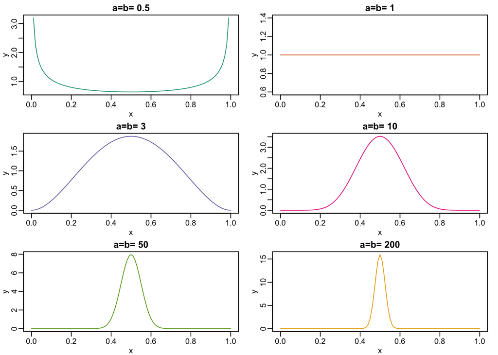

```r
library(rafalib)
mypar(3,2)
x<-seq(0,1,by=0.01)
as<-c(0.5,1,3,10,50,200)
bs<-c(0.5,1,3,10,50,200)
for (i in 1:length(as)){
    y<-dbeta(x,as[i],bs[i])
    plot(x,y,type="l",col=i,main=paste("a=b=",as[i]))
}
```

### Asymmetric beta distributions: $\alpha \ne \beta$

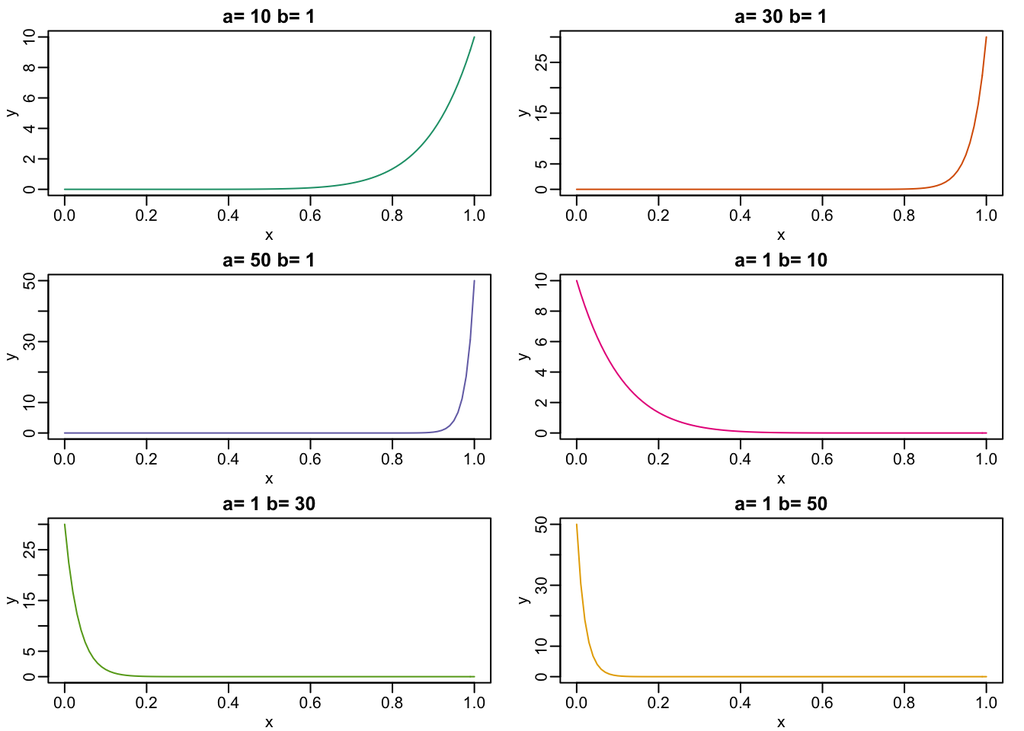

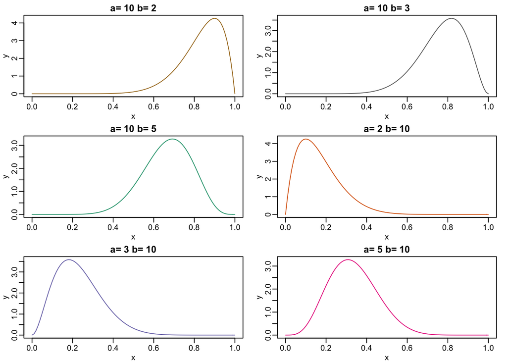

```r
library(rafalib)
mypar(3,2)
as<-c(10,30,50,1,1,1,10,10,10,2,3,5)
bs<-c(1,1,1,10,30,50,2,3,5,10,10,10)
for (i in 1:length(as)){
    y<-dbeta(x,as[i],bs[i])
    plot(x,y,type="l",col=i,main=paste("a=",as[i],"b=",bs[i]))
}
```

### Gamma-Poisson conjugate families

data from Poisson  
prior and posterior from gamma distributions

#### Probability mass function for Poisson distribution

$\lambda$ is the mean *and* the variance

$\lambda > 0$

$P[X=k]=\dfrac{\lambda^k}{k!}\exp(-\lambda)\text{ for }k=1,2,\dots$

### Gamma distribution

Describe continuous non-negative random variables

Parameters for pdf for gamma: shape parameter $k$ and scale parameter $\theta$

#### Mean

$k\theta$

#### Variance

$\theta^2k$

#### New Parameters

If observe Poisson distributed data $x_1, x_2, x_3,\dots x_n$, then updates parameters for the posterior are:

$k^*=k+\sum{x_i}$

$\theta^*=\dfrac{\theta}{n\theta+1}$

### Normal-normal conjugate families

Assume prior on unknown mean $\nu$ is normal, with  
* mean $\mu$  
* standard deviation $\tau$  
Data $x_1,x_2,\dots'x_n$ are independent  
* come from normal with standard deviation $\sigma$

$\mu^*=\dfrac{\mu\sigma^2+n\bar x\tau^2}{\sigma^2+n\tau^2}$

$\tau^*=\sqrt{\dfrac{\sigma^2\tau^2}{\sigma^2+n\tau^2}}$

## Credible Intervals and Predictive Inference

### Credible Intervals

Frequentist: Given a mean and confidence interval, can only say that 95% of similarly constructed confidence intervals will contain the true mean. *Cannnot* say “there is a 95% chance that the true mean lies in a given interval around the point estimate” - either it does, or it does not. True mean is not a random variable.

Bayesian: Treat true mean as a random variable, so *can* say" that “there is a 95 (or other number)% chance that the true mean lies in susch and such a *credible* interval.

Use word *credible* to distinguish from frequentist *confidence* interval

95% credible interval is any *L*, *U* such that posterior probability $p$ is

$L<p<U=0.95$

Shortest such interval is preferable, will often (always?) be asymmetric.

To find interval bounds $L$ and $U$, have to integrate under posterior probabiility density function.

If density is

$f(p)$ for $0 \le p \le 1$

then area under this up to x is the cdf:

$F(x)$ for $0 \le x \le 1$

the Bayesian needs to find $L$, $U$ that give the shortest interval $U$-$L$:

$F(L)-F(U)=0.95$

### Predictive Inference

Often, the real goal is in making a prediction of a future value rather than in making an estimate of a parameter.

Predictive inference arises when the goal is not to find a posterior distribution over some parameter, but rather to find a posterior distribution over some random variable that depends on the parameter.

Specifically, you want to make an inference about a random variable $X$ with probability density function $f(x|\theta)$, where you have some personal probability distribution $\pi(\theta)$ for the $\theta$.

## Losses and Decision Making

### Losses and Decision Making

Bayesian point estimates, losses and decision making.

To a Bayesian, the **posterior distribution** is the basis of any inference, since it integrates both her prior opinions and knowledge *and* the new information provided by the data. It also contains everything she believes about the distribution of the unknown parameter of interest.

But the posterior distribution on its own is not always sufficient.

Sometimes one wants to express one’s inference as a **credible interval** to indicate a range of likely values for the parameter. That would be helpful if you wanted to say that you are 95% certain the probability of an RU-486 pregnancy lies between some number L and some number U.

And on other occasions, one needs to make a single number guess about the value of the parameter. For example, you might want to declare the average payoff for an insurance claim or tell a patient how much longer she has to live.

In such cases, the Bayesian perspective leads directly to **decision theory**. And in decision theory, one seeks to minimize one’s expected loss.

Bayesian may make point estimates of unknown parameters. Will choose the point estimate that minimises the loss. Best estimate depends on the kind of loss function one is using.

How are these best estimates determined?

| Loss | Best estimate |
| --- | --- |
| linear | median |
| square | mean |
| 0/1 | mode |

### Working with Loss Functions

Car dealership: boss wants to know how many cars you will sell in a month. From distribution of previous data (=posterior distribution), over many months, we have the mean, median and mode of monthly car sales for this period. Given this, suppose our guess is $g=30$

Define the loss function:

#### $L_0$ 0/1 Loss

Loss =:

0 if guess $=$ actual loss 1 if guess $\ne$ actual loss

Minimised at the g=*mode* of the posterior

#### $L_1:$ Linear Loss

$L_1(g)=\sum_i{\left|x_i-g\right|}$ Minimised at g = *median* of the posterior

#### $L_2:$ Squared Loss

$L_2(g)=\sum_i{(x_i-g)^2}$ Minimised at g = *mean* of the posterior

### Minimising Expected Loss for Decision Making

#### hypotheses:

$H_1$: Patient does not have HIV  
$H_2$: Patient does have HIV

#### decisions

$d_1$: decide that patient does not have HIV  
$d_2$: decide that patient does have HIV

#### losses

$\begin{aligned} L(d_1)= \left\{ \begin{array}{l} 0 \text{ if patient does not have HIV }\implies d_1 \text{ is right}\\ w_1=1000\text{ if patient does have HIV }\implies d_1 \text{ is wrong} \end{array} \right. \end{aligned}$

$\begin{aligned} L(d_2)= \left\{ \begin{array}{l} 0 \text{ if patient does have HIV }\implies d_2 \text{ is right}\\ w_2=25 \text{ if patient does not have HIV }\implies d_2 \text{ is wrong} \end{array} \right. \end{aligned}$

#### posteriors

$P(H_1|+)=0.88$  
$P(H_2|+)=0.12$

#### expected losses

Expected loss for $d_1$:  
$E[L(d_1)]=$loss if $d_1$ is right $\times$ posterior probability that $H_1$ is right $+$loss if $d_1$ is wrong $\times$ posterior probability that $H_2$ is right $E[L(d_1)]=0\times0.88 + 1000\times 0.12=120$

Hence should decide that patient does have HIV

Bayesian methods allow for the integration of losses into the decision making ramework easily

In Bayesian testing we minimise the posterior expected loss

**Exercise** Suppose $w_1=100$ and $w_2=50$. Which decision minimises loss?

```r
ELd1=0*0.88 + 100*0.12
ELd2=0*0.12 + 50*0.88
c(ELd1,ELd2)
```

```
## [1] 12 44
```

### Posterior probabilities of hypotheses and Bayes factors

**prior odds**=ratio of prior hypotheses we are considering
$$O[H_1:H_2]=\dfrac{P(H_1)}{P(H_2)}$$

**posterior odds**=ratio of the two posterior probabilities of these hypotheses

$$\begin{aligned}
PO[H_1:H_2]&=\dfrac{P(H_1|data)}{P(H_2|data)}\\
\\
&=\dfrac{\left(P(data|H_1)P(H_1)\right)/P(data)}{\left(P(data|H_2)P(H_2)\right)/P(data)}\\
\\
&=\dfrac{P(data|H_1)}{P(data|H_2)}\times\dfrac{P(H_1)}{P(H_2)}\\
\\
&=\text{Bayes Factor}\times\text{Prior Odds}\\
\\
PO[H_1:H_2]&=BF[H_1:H_2]\times O[H_1:H_2]
\end{aligned}$$